# BS_Behavioral

Now that we have cleaned up our data and combined the CATS and behavioral data sets, we need to fill in the behaviors that are currently missing for every other timestamp (since we set it up so that we only had a behavior assigned to the time when it started)

```r
# for loop for filling in behaviors
for (i in 1:nrow(fulldat)) {
  if(is.na(fulldat[i,]$Behavior)==TRUE){
    fulldat[i,]$Behavior <- fulldat[(i-1),]$Behavior
  }
}

summary(fulldat)
```

```
##     Pressure            Sway             Surge              Heave
##  Min.   : -964.4   Min.   :-0.9941   Min.   :-1.03320   Min.   :-1.2402
##  1st Qu.:  319.9   1st Qu.: 0.1426   1st Qu.:-0.39258   1st Qu.: 0.8418
##  Median :  497.1   Median : 0.2051   Median :-0.29297   Median : 0.8945
##  Mean   : 5405.9   Mean   : 0.2009   Mean   :-0.14661   Mean   : 0.8725
##  3rd Qu.: 2208.9   3rd Qu.: 0.2598   3rd Qu.: 0.03125   3rd Qu.: 0.9336
##  Max.   :85853.2   Max.   : 0.8008   Max.   : 1.31836   Max.   : 1.6875
##
##      Light       Temperature         ODBA                 Time
##  Min.   : 130   Min.   : 1.00   Min.   :-1.7701823   Min.   :19:49:10
##  1st Qu.:3500   1st Qu.:15.25   1st Qu.:-0.0208333   1st Qu.:20:43:09
##  Median :3500   Median :15.75   Median : 0.0006510   Median :21:37:16
##  Mean   :3044   Mean   :15.73   Mean   :-0.0004755   Mean   :21:37:17
##  3rd Qu.:3500   3rd Qu.:16.12   3rd Qu.: 0.0227865   3rd Qu.:22:31:24
##  Max.   :3500   Max.   :20.94   Max.   : 1.0735677   Max.   :23:25:32
##
##                     Behavior    Comments
##  Straight swim          :6618   Mode:logical
##  Out of water           :1187   NA's:12998
##  Feed                   :1169
##  Swim along ground      :1037
##  Conspecific interaction: 795
##  Left turn              : 795
##  (Other)                :1397
```

```r
### need to get rid of all behaviors that are "out of water"
fulldat <- fulldat[fulldat$Behavior!="Out of water",]
summary(fulldat$Behavior) #note: behavior is still kept here as a level for the factor, which should be fine
```

```
## Conspecific interaction                    Feed               Left turn
##                     795                    1169                     795
##        Lturn while feed            Out of water              Right turn
##                     173                       0                     488
##        Rturn while feed           Straight swim                 Swallow
##                     237                    6618                     499
##       Swim along ground
##                    1037
```

```r
### We now have a data set that contains all behaviors ###
```

** Data Cleaning Done** Time to divide the water column to look at relevant behaviors in each

```r
#### if we keep it simple: feed vs. non-feeding
fulldat$feeding <- ifelse (fulldat$Behavior == "Feed"|fulldat$Behavior == "Lturn while feed"| fulldat$Behavior == "Rturn while feed"| fulldat$Behavior == "Swallow", 1, 0)


# convert pressure (mB) to depth
#fulldat$Pressure2 <- abs(fulldat$Pressure*0.010197442889221)
#range(fulldat$Pressure2)

topdat <- fulldat[fulldat$Pressure<320,]
midtopdat <- fulldat[fulldat$Pressure>=320 & fulldat$Pressure<500,]
lowtopdat <- fulldat[fulldat$Pressure>=500 & fulldat$Pressure<2200,]
lowdat <- fulldat[fulldat$Pressure>=2200,]

# now for each, we want to look at the percentage of time that the shark exhibits certain behaviors here
```

Breakdown of behaviors

```r
## Assuming each row is 1 second. Double check this:
(fulldat$Time[nrow(fulldat)] - fulldat$Time[1]) #[1] 03:36:22
```

```
## [1] 03:36:22
```

```r
nrow(fulldat)
```

```
## [1] 11811
```

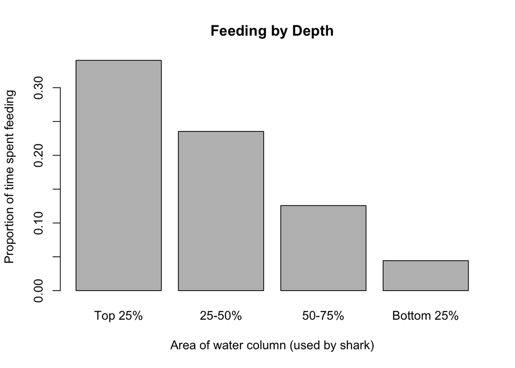

```r
### if each row is a second, then the number of times each behavior is assigned to a second should give us the duration of that behavior over time

##################### TOP OF WATER COLUMN ##############
time1 <- nrow(topdat)/nrow(fulldat) #indicates that out of all time, sharks spends 20% in upper part of water column

# percent feeding vs. nonfeeding
topfeed <- topdat[topdat$feeding==1,]
feed1<- nrow(topfeed)/nrow(topdat) #34%

##################### 2nd part OF WATER COLUMN ##############
time2 <- nrow(midtopdat)/nrow(fulldat) #indicates that out of all time, sharks spends 25% in 25-50% quartile depth range

# percent feeding vs. nonfeeding
midtopfeed <- midtopdat[midtopdat$feeding==1,]
feed2<- nrow(midtopfeed)/nrow(midtopdat) #23%

##################### 3rd part OF WATER COLUMN ##############
time3 <- nrow(lowtopdat)/nrow(fulldat) #indicates that out of all time, sharks spends 26% in 50-75% quartile depth range

# percent feeding vs. nonfeeding
lowtopfeed <- lowtopdat[lowtopdat$feeding==1,]
feed3 <- nrow(lowtopfeed)/nrow(lowtopdat) #12%

##################### 4th part OF WATER COLUMN ##############
time4 <- nrow(lowdat)/nrow(fulldat) #indicates that out of all time, sharks spends 27% time in lowest quartile depth range (no shit - need to think about a biologically relevant way to divide up the water column)

# percent feeding vs. nonfeeding
lowfeed <- lowtopdat[lowdat$feeding==1,]
feed4 <- nrow(lowfeed)/nrow(lowdat) #04%

### this is interesting because it seems like they still spend half of the time in the water column in areas where they are feeding minimally

# Plot the feeding percentage as a function of area in the water column
feedgraph <- barplot(height=c(feed1, feed2, feed3,feed4), names.arg=(c("Top 25%", "25-50%", "50-75%", "Bottom 25%")), xlab="Area of water column (used by shark)", ylab="Proportion of time spent feeding", main="Feeding by Depth")
```

Here we see that feeding time (vs. all other behaviors (swimming and turning)) decreases by depth, which makes intuitive sense. It would be interesting to consider the environmental context in which this occurs (likely feeding only in the plankton layer).

We also have other data on more nuanced behaviors. One hypothesis is that it’s more energetically efficient to travel at depth. If this is the case, we might hypothesize that there would be fewer turns at depth than at the surface. We can also look at straight swimming (i.e. no turning) vs. feeding.

```r
# top 25% water column
topturn <- topdat[topdat$Behavior=="Right turn"|topdat$Behavior=="Left turn"|topdat$Behavior=="Rturn while feed"|topdat$Behavior=="Lturn while feed",]
turn1<- nrow(topturn)/nrow(topdat)
turn1 #.18
```

```
## [1] 0.1791531
```

```r
# 25-50% water column
midtopturn <- midtopdat[midtopdat$Behavior=="Right turn"|midtopdat$Behavior=="Left turn"|midtopdat$Behavior=="Rturn while feed"|midtopdat$Behavior=="Lturn while feed",]
turn2<- nrow(midtopturn)/nrow(midtopdat)
turn2 #.15
```

```
## [1] 0.1548643
```

```r
lowtopturn <- lowtopdat[lowtopdat$Behavior=="Right turn"|lowtopdat$Behavior=="Left turn"|lowtopdat$Behavior=="Rturn while feed"|lowtopdat$Behavior=="Lturn while feed",]
turn3<- nrow(lowtopturn)/nrow(lowtopdat)
turn3 #.11
```

```
## [1] 0.1195193
```

```r
lowturn <- lowdat[lowdat$Behavior=="Right turn"|lowdat$Behavior=="Left turn"|lowdat$Behavior=="Rturn while feed"|lowdat$Behavior=="Lturn while feed",]
turn4<- nrow(lowturn)/nrow(lowdat)
turn4 #.12
```

```
## [1] 0.12815
```

```r
## Okay, so out of all the behaviors, it doesn't seem like turning changes very much based on depth. Now let's compare to just straight swimming

# First need to set up the "straight swim" data
# top 25% water column
topswim <- topdat[topdat$Behavior=="Straight swim",]
swim1<- nrow(topswim)/nrow(topdat)
swim1 #.50
```

```
## [1] 0.5052932
```

```r
# 25-50% water column
midtopswim <- midtopdat[midtopdat$Behavior=="Straight swim",]
swim2<- nrow(midtopswim)/nrow(midtopdat)
swim2 #.62
```

```
## [1] 0.6247518
```

```r
lowtopswim <- lowtopdat[lowtopdat$Behavior=="Straight swim",]
swim3<- nrow(lowtopswim)/nrow(lowtopdat)
swim3 #.64
```

```
## [1] 0.6469633
```

```r
lowswim <- lowdat[lowdat$Behavior=="Straight swim",]
swim4<- nrow(lowswim)/nrow(lowdat)
swim4 #.46
```

```
## [1] 0.4600492
```

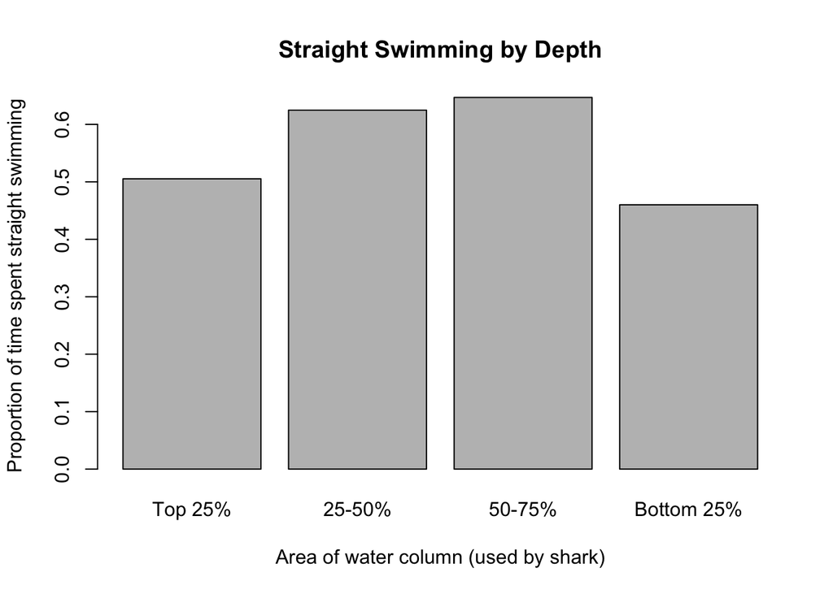

```r
# plotting the swim data
swimgraph <- barplot(height=c(swim1, swim2, swim3,swim4), names.arg=(c("Top 25%", "25-50%", "50-75%", "Bottom 25%")), xlab="Area of water column (used by shark)", ylab="Proportion of time spent straight swimming", main="Straight Swimming by Depth")
```

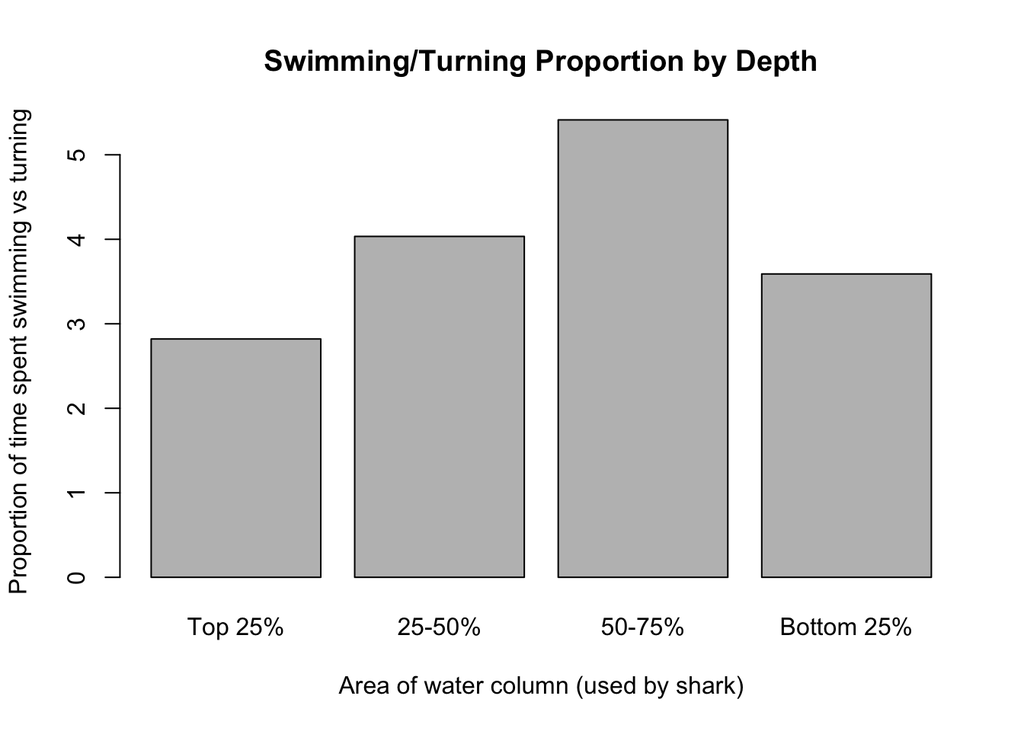

```r
# plotting the swim vs. turning proportion
st1 <-nrow(topswim)/nrow(topturn)
st2 <- nrow(midtopswim)/nrow(midtopturn)
st3 <- nrow(lowtopswim)/nrow(lowtopturn)
st4 <- nrow(lowswim)/nrow(lowturn)

stgraph <- barplot(height=c(st1, st2, st3, st4), names.arg=(c("Top 25%", "25-50%", "50-75%", "Bottom 25%")), xlab="Area of water column (used by shark)", ylab="Proportion of time spent swimming vs turning", main="Swimming/Turning Proportion by Depth")
```

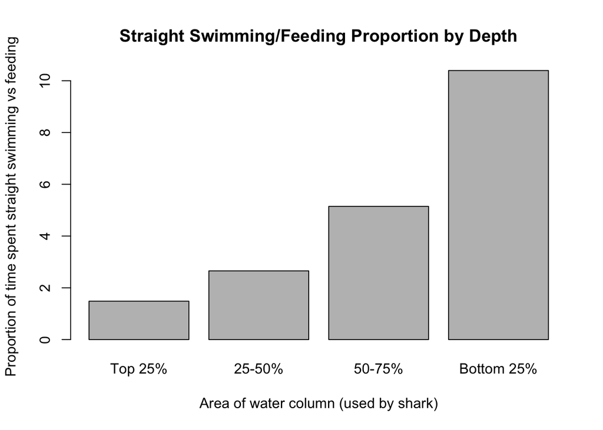

```r
# plotting the swim vs. feeding proportion
sf1 <-nrow(topswim)/nrow(topfeed)
sf2 <- nrow(midtopswim)/nrow(midtopfeed)
sf3 <- nrow(lowtopswim)/nrow(lowtopfeed)
sf4 <- nrow(lowswim)/nrow(lowfeed)

sfgraph <- barplot(height=c(sf1, sf2, sf3, sf4), names.arg=(c("Top 25%", "25-50%", "50-75%", "Bottom 25%")), xlab="Area of water column (used by shark)", ylab="Proportion of time spent straight swimming vs feeding", main="Straight Swimming/Feeding Proportion by Depth")
```

```r
# note that this is NOT taking into account turns
```

Summary based on graphs: 1) Turning doesn’t change much by depth 2) Straight swimming (no turns) seems to happen in the middle part of the water column 3) However, the proportion of straight swimming (no turns) to feeding is largest at depth

Another interesting behavior to look at would be swallowing - are the sharks sampling? Or are they merely swallowing? From observation, it seems like they don’t *always* continue feeding afterwards. Let’s look at where most of the swallowing happens as it compares to where the feeding tends to happen.

```r
# First need to set up the "straight swim" data
# top 25% water column
topswal <- topdat[topdat$Behavior=="Swallow",]
swal1<- nrow(topswal)/nrow(topdat)
swal1 #.03
```

```
## [1] 0.03460912
```

```r
# 25-50% water column
midtopswal <- midtopdat[midtopdat$Behavior=="Swallow",]
swal2<- nrow(midtopswal)/nrow(midtopdat)
swal2 #.04
```

```
## [1] 0.04566512
```

```r
lowtopswal <- lowtopdat[lowtopdat$Behavior=="Swallow",]
swal3<- nrow(lowtopswal)/nrow(lowtopdat)
swal3 #.04
```

```
## [1] 0.04839234
```

```r
lowswal <- lowdat[lowdat$Behavior=="Swallow",]
swal4<- nrow(lowswal)/nrow(lowdat)
swal4 #.03
```

```
## [1] 0.03902889
```

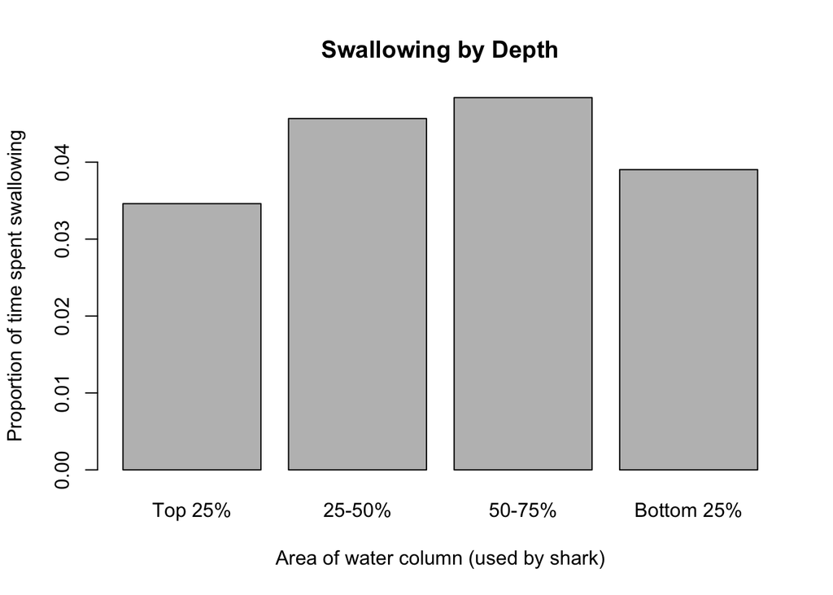

```r
# plotting the swallow data
swalgraph <- barplot(height=c(swal1, swal2, swal3,swal4), names.arg=(c("Top 25%", "25-50%", "50-75%", "Bottom 25%")), xlab="Area of water column (used by shark)", ylab="Proportion of time spent swallowing", main="Swallowing by Depth")
```

The results here suggest that swallowing doesn’t change much by depth, which is *interesting* because we know that feeding changes drastically by depth. So why would they swallow near the sea bed? This supports the hypothesis for sampling, rather than just swallowing food.

Now let’s put all the graphs together for ease of visualization.

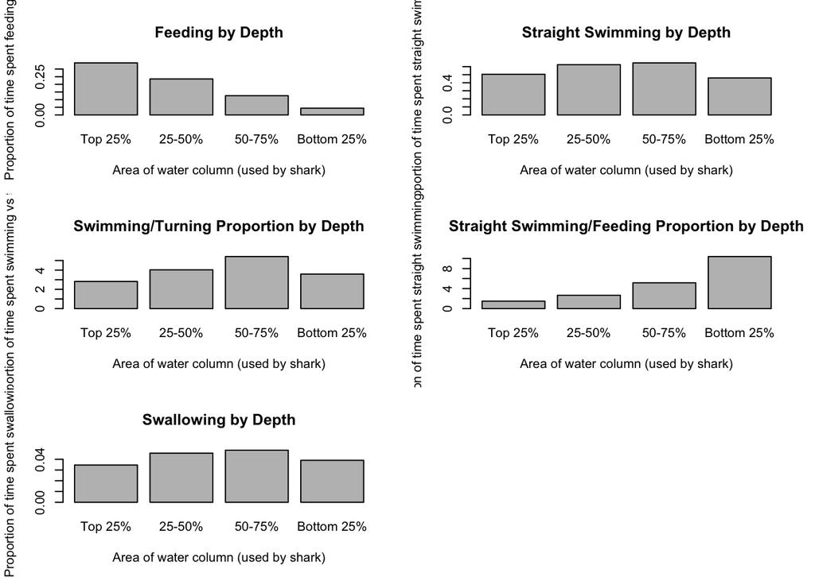

```r
par(mfrow=c(3,2))
barplot(height=c(feed1, feed2, feed3,feed4), names.arg=(c("Top 25%", "25-50%", "50-75%", "Bottom 25%")), xlab="Area of water column (used by shark)", ylab="Proportion of time spent feeding", main="Feeding by Depth")

barplot(height=c(swim1, swim2, swim3,swim4), names.arg=(c("Top 25%", "25-50%", "50-75%", "Bottom 25%")), xlab="Area of water column (used by shark)", ylab="Proportion of time spent straight swimming", main="Straight Swimming by Depth")

barplot(height=c(st1, st2, st3, st4), names.arg=(c("Top 25%", "25-50%", "50-75%", "Bottom 25%")), xlab="Area of water column (used by shark)", ylab="Proportion of time spent swimming vs turning", main="Swimming/Turning Proportion by Depth")

barplot(height=c(sf1, sf2, sf3, sf4), names.arg=(c("Top 25%", "25-50%", "50-75%", "Bottom 25%")), xlab="Area of water column (used by shark)", ylab="Proportion of time spent straight swimming vs feeding", main="Straight Swimming/Feeding Proportion by Depth")

barplot(height=c(swal1, swal2, swal3,swal4), names.arg=(c("Top 25%", "25-50%", "50-75%", "Bottom 25%")), xlab="Area of water column (used by shark)", ylab="Proportion of time spent swallowing", main="Swallowing by Depth")
```

Now let’s look at characteristics of each of these parts of the water column.

```r
summary(fulldat)
```

```
##     Pressure            Sway             Surge              Heave
##  Min.   : -964.4   Min.   :-0.9941   Min.   :-1.03320   Min.   :-1.2402
##  1st Qu.:  352.2   1st Qu.: 0.1504   1st Qu.:-0.38867   1st Qu.: 0.8477
##  Median :  530.1   Median : 0.2070   Median :-0.29492   Median : 0.8945
##  Mean   : 5921.5   Mean   : 0.2070   Mean   :-0.15670   Mean   : 0.8740
##  3rd Qu.: 3243.0   3rd Qu.: 0.2637   3rd Qu.:-0.05469   3rd Qu.: 0.9316
##  Max.   :85853.2   Max.   : 0.8008   Max.   : 1.08984   Max.   : 1.6875
##
##      Light       Temperature         ODBA                 Time
##  Min.   : 130   Min.   : 1.00   Min.   :-1.7701823   Min.   :19:49:10
##  1st Qu.:3500   1st Qu.:15.19   1st Qu.:-0.0201823   1st Qu.:20:53:57
##  Median :3500   Median :15.75   Median : 0.0000000   Median :21:47:09
##  Mean   :2998   Mean   :15.72   Mean   :-0.0005602   Mean   :21:42:42
##  3rd Qu.:3500   3rd Qu.:16.12   3rd Qu.: 0.0214844   3rd Qu.:22:36:20
##  Max.   :3500   Max.   :20.94   Max.   : 0.5156250   Max.   :23:25:32
##
##                     Behavior    Comments          feeding
##  Straight swim          :6618   Mode:logical   Min.   :0.0000
##  Feed                   :1169   NA's:11811     1st Qu.:0.0000
##  Swim along ground      :1037                  Median :0.0000
##  Conspecific interaction: 795                  Mean   :0.1759
##  Left turn              : 795                  3rd Qu.:0.0000
##  Swallow                : 499                  Max.   :1.0000
##  (Other)                : 898
```

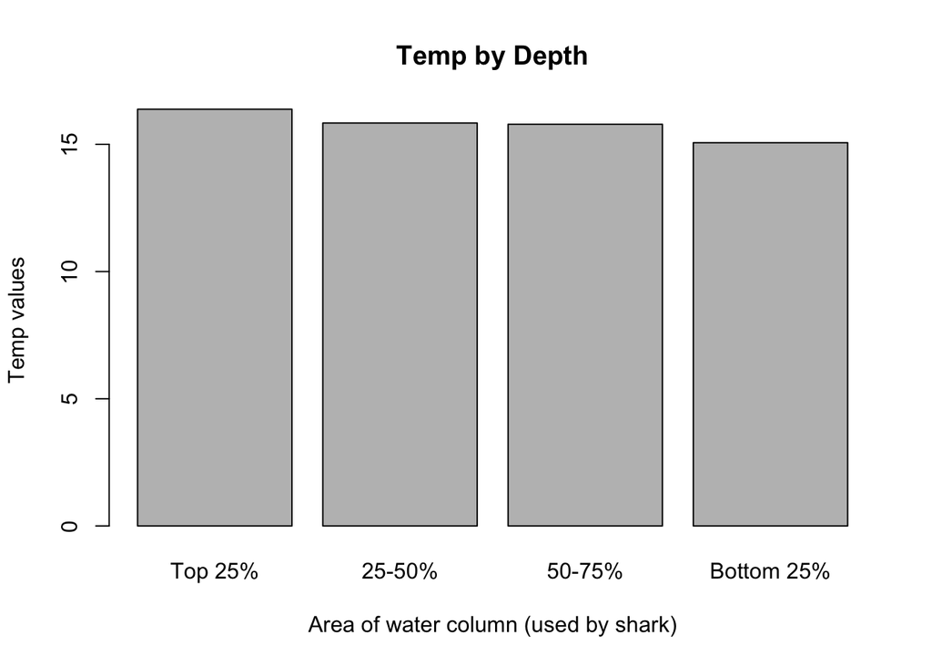

```r
barplot(height=c(mean(topdat$Temperature), mean(midtopdat$Temperature), mean(lowtopdat$Temperature), mean(lowdat$Temperature)), names.arg=(c("Top 25%", "25-50%", "50-75%", "Bottom 25%")), xlab="Area of water column (used by shark)", ylab="Temp values", main="Temp by Depth")
```

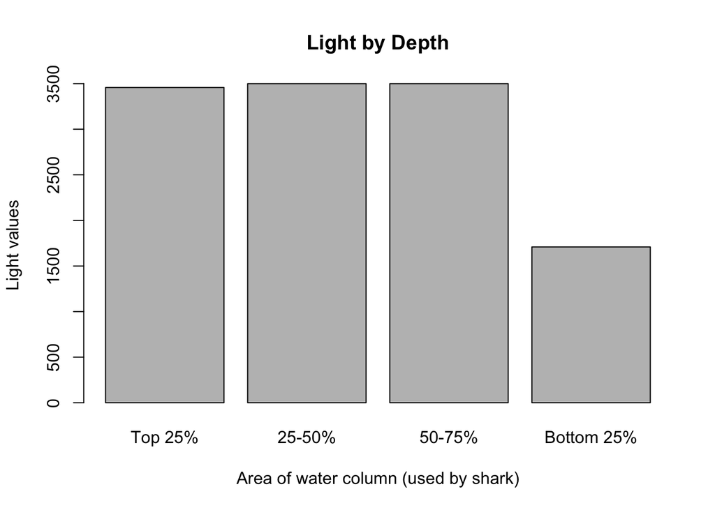

```r
#almost no change in mean temperature (water fully mixed)

barplot(height=c(mean(topdat$Light), mean(midtopdat$Light), mean(lowtopdat$Light), mean(lowdat$Light)), names.arg=(c("Top 25%", "25-50%", "50-75%", "Bottom 25%")), xlab="Area of water column (used by shark)", ylab="Light values", main="Light by Depth")
```

```r
# drops off drastically in the bottom quarter of the area used by the shark
```

But, let’s look briefly at the mean values from the accelerometer data.

```r
# If we are interested in tailbeat frequency (raw accelerometer values, unfiltered), we can take a quick look at the range in sway values
range(topdat$Sway)
```

```
## [1] -0.9941406  0.6152344
```

```r
sw1 <- range(topdat$Sway)[2] + abs(range(topdat$Sway)[1])
sw1
```

```
## [1] 1.609375
```

```r
range(midtopdat$Sway)
```

```
## [1] -0.5566406  0.4335938
```

```r
sw2 <- range(midtopdat$Sway)[2] + abs(range(midtopdat$Sway)[1])
sw2
```

```
## [1] 0.9902344
```

```r
range(lowtopdat$Sway)
```

```
## [1] -0.02148438  0.70117188
```

```r
sw3 <- range(lowtopdat$Sway)[2] + abs(range(lowtopdat$Sway)[1])
sw3
```

```
## [1] 0.7226562
```

```r
range(lowdat$Sway)
```

```
## [1] -0.2050781  0.8007812
```

```r
sw4 <- range(lowdat$Sway)[2] + abs(range(lowdat$Sway)[1])
sw4
```

```
## [1] 1.005859
```

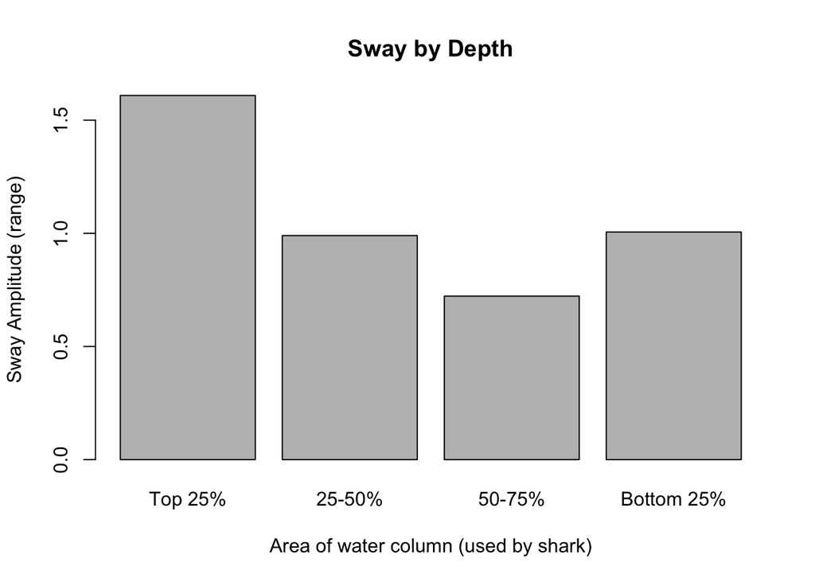

```r
barplot(height=c(sw1, sw2, sw3, sw4), names.arg=(c("Top 25%", "25-50%", "50-75%", "Bottom 25%")), xlab="Area of water column (used by shark)", ylab="Sway Amplitude (range)", main="Sway by Depth")
```

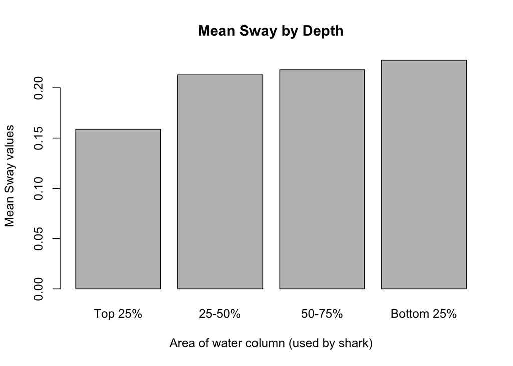

```r
# Note: I'm assuming that the range of sway values is more indicative of amplitude...not sure if that's the case, so I also looked at mean.
barplot(height=c(mean(topdat$Sway), mean(midtopdat$Sway), mean(lowtopdat$Sway), mean(lowdat$Sway)), names.arg=(c("Top 25%", "25-50%", "50-75%", "Bottom 25%")), xlab="Area of water column (used by shark)", ylab="Mean Sway values", main="Mean Sway by Depth")
```

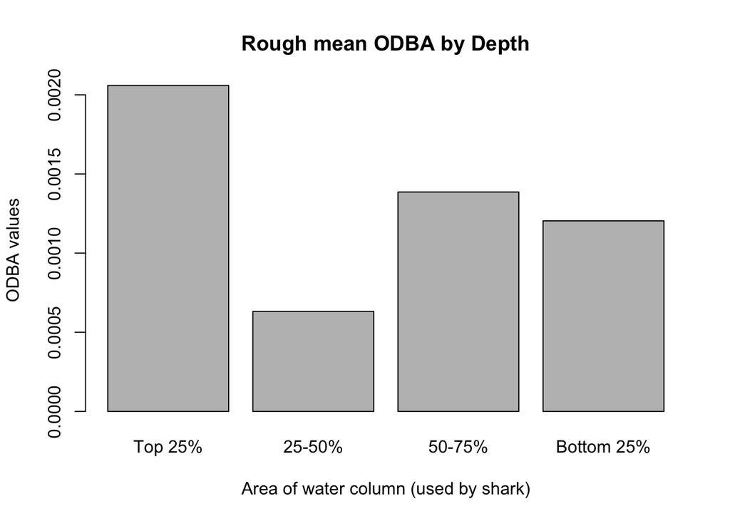

```r
# And, just for kicks: ODBA
barplot(height=c(abs(mean(topdat$ODBA)), abs(mean(midtopdat$ODBA)), abs(mean(lowtopdat$ODBA)), abs(mean(lowdat$ODBA))), names.arg=(c("Top 25%", "25-50%", "50-75%", "Bottom 25%")), xlab="Area of water column (used by shark)", ylab="ODBA values", main="Rough mean ODBA by Depth")
```

**Now to do the same thing for Shark 2**

```r
setwd("~/Box Sync/BaskingShark_behaviors")
ID <- 2
data <- read.csv(paste0("Shark ", ID, "_CATS_behaviors.csv"))

head(data, 20)
```

```
##        Date          Time Digital.Time X0.Feeding.1.Not.Feeding
## 1  26.07.13 19:16:45:0000     19.26742                        0
## 2  26.07.13 19:16:45:0050     19.26792                        0
## 3  26.07.13 19:16:45:0100     19.26842                        0
## 4  26.07.13 19:16:45:0150     19.26892                        0
## 5  26.07.13 19:16:45:0200     19.26942                        0
## 6  26.07.13 19:16:45:0250     19.26992                        0
## 7  26.07.13 19:16:45:0300     19.27042                        0
## 8  26.07.13 19:16:45:0350     19.27092                        0
## 9  26.07.13 19:16:45:0400     19.27142                        0
## 10 26.07.13 19:16:45:0450     19.27192                        0
## 11 26.07.13 19:16:45:0500     19.27242                        0
## 12 26.07.13 19:16:45:0550     19.27292                        0
## 13 26.07.13 19:16:45:0600     19.27342                        0
## 14 26.07.13 19:16:45:0650     19.27392                        0
```

[output cut: 174 more lines]

```r
class(data$Time)
```

```
## [1] "factor"
```

```r
summary(data)
```

```
##        Date                   Time         Digital.Time
##  26.07.13:208859   19:16:45:0000:     1   Min.   :19.27
##                    19:16:45:0050:     1   1st Qu.:20.00
##                    19:16:45:0100:     1   Median :20.72
##                    19:16:45:0150:     1   Mean   :20.73
##                    19:16:45:0200:     1   3rd Qu.:21.45
##                    19:16:45:0250:     1   Max.   :22.18
##                    (Other)      :208853
##  X0.Feeding.1.Not.Feeding Pressure...channel..1 Compass..1....channel..1
##  Min.   :0.0000           Min.   :-29058        Min.   :-1007.0
##  1st Qu.:0.0000           1st Qu.:-27447        1st Qu.: -490.0
##  Median :0.0000           Median :-26760        Median : -128.0
##  Mean   :0.2243           Mean   :-20233        Mean   : -103.7
##  3rd Qu.:0.0000           3rd Qu.:-13046        3rd Qu.:  304.0
##  Max.   :1.0000           Max.   : 62946        Max.   :  684.0
##
##  Compass..1....channel..2 Compass..1....channel..3
##  Min.   :-773.0           Min.   :-1504.0
##  1st Qu.:-534.0           1st Qu.: -523.5
##  Median :-336.0           Median :  202.0
##  Mean   :-289.8           Mean   :  165.7
##  3rd Qu.: -31.0           3rd Qu.:  886.0
##  Max.   : 302.0           Max.   : 1715.0
##
##  Acceleration..1....channel..1 Acceleration..1....channel..2
##  Min.   :-7072                 Min.   :-13632
##  1st Qu.:-1616                 1st Qu.: -3904
##  Median :-1088                 Median : -3056
##  Mean   :-1054                 Mean   : -2733
##  3rd Qu.: -512                 3rd Qu.: -2032
##  Max.   : 8080                 Max.   : 17328
##
##  Acceleration..1....channel..3 Temperature..1....channel..1
##  Min.   :-7840                 Min.   : 128.0
##  1st Qu.: 3712                 1st Qu.: 192.0
##  Median : 4160                 Median : 256.0
##  Mean   : 4068                 Mean   : 360.2
##  3rd Qu.: 4496                 3rd Qu.: 448.0
##  Max.   : 8544                 Max.   :1792.0
##
```

[output cut: 25 more lines]

```
##  Min.   :60864                Min.   : 100
##  1st Qu.:61072                1st Qu.:1329
##  Median :61248                Median :3500
##  Mean   :61484                Mean   :2668
##  3rd Qu.:61696                3rd Qu.:3500
##  Max.   :65344                Max.   :3500
##
##  Temperature.ext....channel..1      ODBA
##  Min.   : 0.125                Min.   :-11360.000
##  1st Qu.:15.375                1st Qu.:  -122.667
##  Median :15.562                Median :     5.333
##  Mean   :15.705                Mean   :    -0.022
##  3rd Qu.:15.875                3rd Qu.:   128.000
##  Max.   :29.750                Max.   : 11962.667
##
```

```r
#clean up data so we only get what we need
data <- data[,c("Time", "Pressure...channel..1", "Acceleration..1....channel..1", "Acceleration..1....channel..2", "Acceleration..1....channel..3","Acceleration..2....channel..1","Acceleration..2....channel..2", "Acceleration..2....channel..3", "Light.intensity...channel..1", "Temperature.ext....channel..1", "ODBA")]


# This is at 20 Hz. We want to extract every 20th value and get rid of milliseconds
data2 <- data[seq(1, nrow(data), 20),]
vector <- as.character(data2$Time)
data2$Time <- substr(vector, 1, 8)
head(data2$Time)
```

```
## [1] "19:16:45" "19:16:46" "19:16:47" "19:16:48" "19:16:49" "19:16:50"
```

```r
head(data2)
```

```
##         Time Pressure...channel..1 Acceleration..1....channel..1
## 1   19:16:45             -28837.89                          1408
## 21  19:16:46             -28853.16                          1152
## 41  19:16:47             -28810.79                          2640
## 61  19:16:48             -28829.57                          2016
## 81  19:16:49             -28839.37                          2528
## 101 19:16:50             -28838.75                          2720
##     Acceleration..1....channel..2 Acceleration..1....channel..3
## 1                            -960                          4544
## 21                           -224                          4784
## 41                          -2192                          5808
## 61                          -2000                          5088
## 81                          -1184                          4512
## 101                         -1328                          4496
##     Acceleration..2....channel..1 Acceleration..2....channel..2
```

[output cut: 20 more lines]

```r
# make into chron object so that we can merge the behavioral data according to timestamp
# needed to make as a character first so that chron recognizes the format
#install.packages("chron")
library(chron)
data2$chron<- chron(times. = data2$Time, format ="hh:mm:ss", out.format = "h:m:s")
data2$chron
```

```
##     [1] 19:16:45 19:16:46 19:16:47 19:16:48 19:16:49 19:16:50 19:16:51
##     [8] 19:16:52 19:16:53 19:16:54 19:16:55 19:16:56 19:16:57 19:16:58
##    [15] 19:16:59 19:17:00 19:17:01 19:17:02 19:17:03 19:17:04 19:17:05
##    [22] 19:17:06 19:17:07 19:17:08 19:17:09 19:17:10 19:17:11 19:17:12
##    [29] 19:17:13 19:17:14 19:17:15 19:17:16 19:17:17 19:17:18 19:17:19
##    [36] 19:17:20 19:17:21 19:17:22 19:17:23 19:17:24 19:17:25 19:17:26
##    [43] 19:17:27 19:17:28 19:17:29 19:17:30 19:17:31 19:17:32 19:17:33
##    [50] 19:17:34 19:17:35 19:17:36 19:17:37 19:17:38 19:17:39 19:17:40
##    [57] 19:17:41 19:17:42 19:17:43 19:17:44 19:17:45 19:17:46 19:17:47
##    [64] 19:17:48 19:17:49 19:17:50 19:17:51 19:17:52 19:17:53 19:17:54
##    [71] 19:17:55 19:17:56 19:17:57 19:17:58 19:17:59 19:18:00 19:18:01
##    [78] 19:18:02 19:18:03 19:18:04 19:18:05 19:18:06 19:18:07 19:18:08
##    [85] 19:18:09 19:18:10 19:18:11 19:18:12 19:18:13 19:18:14 19:18:15
##    [92] 19:18:16 19:18:17 19:18:18 19:18:19 19:18:20 19:18:21 19:18:22
##    [99] 19:18:23 19:18:24 19:18:25 19:18:26 19:18:27 19:18:28 19:18:29
```

[output cut: 1477 more lines]

```r
class(data2$chron)
```

```
## [1] "times"
```

```r
##########################################
### let's read in the behavioral data now
##########################################
behavior <- read.csv("CATS_S2_Events.csv")
head(behavior)
```

```
##      Time      Behavior Comment
## 1 293.447 Straight swim      NA
## 2 311.315         Rturn      NA
## 3 314.265          Feed      NA
## 4 315.065  Out of water      NA
## 5 317.215         Lturn      NA
## 6 335.140 Straight swim      NA
```

```r
class(behavior$Time)
```

```
## [1] "numeric"
```

```r
# use this function (found on internet) to generate time values from the seconds values in the behavior data
dhms <- function(t){
    paste(t %/% (60*60*24)
         ,paste(formatC(t %/% (60*60) %% 24, width = 2, format = "d", flag = "0")
               ,formatC(t %/% 60 %% 60, width = 2, format = "d", flag = "0")
               ,formatC(t %% 60, width = 2, format = "d", flag = "0")
               ,sep = ":"
               )
         )
}


behavior$Time <- dhms(behavior$Time)
head(behavior$Time)
```

```
## [1] "0 00:04:53" "0 00:05:11" "0 00:05:14" "0 00:05:15" "0 00:05:17"
## [6] "0 00:05:35"
```

```r
# clean it up
vector2 <- as.character(behavior$Time)
behavior$Time <- substr(vector2, 3, 10) #this allows you to get rid of objects within a character string (only want the 3-10 values in the character string)
head(behavior$Time)
```

```
## [1] "00:04:53" "00:05:11" "00:05:14" "00:05:15" "00:05:17" "00:05:35"
```

```r
# now make this into a chron object
behavec <- chron(times. = behavior$Time, format ="hh:mm:ss", out.format = "h:m:s")
head(behavec)
```

```
## [1] 00:04:53 00:05:11 00:05:14 00:05:15 00:05:17 00:05:35
```

```r
#### We want to add all of these times to the start time from the data
behavior$Time2 <- behavec + data2$chron[1]
head(behavior$Time2)
```

```
## [1] 19:21:38 19:21:56 19:21:59 19:22:00 19:22:02 19:22:20
```

```r
head(behavior)
```

```
##       Time      Behavior Comment    Time2
## 1 00:04:53 Straight swim      NA 19:21:38
## 2 00:05:11         Rturn      NA 19:21:56
## 3 00:05:14          Feed      NA 19:21:59
## 4 00:05:15  Out of water      NA 19:22:00
## 5 00:05:17         Lturn      NA 19:22:02
## 6 00:05:35 Straight swim      NA 19:22:20
```

```r
class(behavior$Time2)
```

```
## [1] "times"
```

```r
## clean up data so that we only have behavior, comments and time2 columns
behavior2 <- behavior[,(2:4)]
head(behavior2)
```

```
##        Behavior Comment    Time2
## 1 Straight swim      NA 19:21:38
## 2         Rturn      NA 19:21:56
## 3          Feed      NA 19:21:59
## 4  Out of water      NA 19:22:00
## 5         Lturn      NA 19:22:02
## 6 Straight swim      NA 19:22:20
```

```r
colnames(behavior2) <- c("Behavior", "Comment", "chron")
head(behavior2)
```

```
##        Behavior Comment    chron
## 1 Straight swim      NA 19:21:38
## 2         Rturn      NA 19:21:56
## 3          Feed      NA 19:21:59
## 4  Out of water      NA 19:22:00
## 5         Lturn      NA 19:22:02
## 6 Straight swim      NA 19:22:20
```

```r
##############################
# Check out all of the columns in both datasets to make sure we can merge them #
############################
# CATS data
head(data2) # going to merge using the "chron" column
```

```
##         Time Pressure...channel..1 Acceleration..1....channel..1
## 1   19:16:45             -28837.89                          1408
## 21  19:16:46             -28853.16                          1152
## 41  19:16:47             -28810.79                          2640
## 61  19:16:48             -28829.57                          2016
## 81  19:16:49             -28839.37                          2528
## 101 19:16:50             -28838.75                          2720
##     Acceleration..1....channel..2 Acceleration..1....channel..3
## 1                            -960                          4544
## 21                           -224                          4784
## 41                          -2192                          5808
## 61                          -2000                          5088
## 81                          -1184                          4512
## 101                         -1328                          4496
##     Acceleration..2....channel..1 Acceleration..2....channel..2
```

[output cut: 20 more lines]

```r
# behavior data
head(behavior2) #going to merge using "chron" column
```

```
##        Behavior Comment    chron
## 1 Straight swim      NA 19:21:38
## 2         Rturn      NA 19:21:56
## 3          Feed      NA 19:21:59
## 4  Out of water      NA 19:22:00
## 5         Lturn      NA 19:22:02
## 6 Straight swim      NA 19:22:20
```

```r
# now to join
library(tidyverse)
library(dplyr)
fulldat <- left_join(data2, behavior2, by= c("chron"="chron"))
head(fulldat)
```

```
##       Time Pressure...channel..1 Acceleration..1....channel..1
## 1 19:16:45             -28837.89                          1408
## 2 19:16:46             -28853.16                          1152
## 3 19:16:47             -28810.79                          2640
## 4 19:16:48             -28829.57                          2016
## 5 19:16:49             -28839.37                          2528
## 6 19:16:50             -28838.75                          2720
##   Acceleration..1....channel..2 Acceleration..1....channel..3
## 1                          -960                          4544
## 2                          -224                          4784
## 3                         -2192                          5808
## 4                         -2000                          5088
## 5                         -1184                          4512
## 6                         -1328                          4496
##   Acceleration..2....channel..1 Acceleration..2....channel..2
```

[output cut: 20 more lines]

```r
fulldat <- fulldat[,-1]
head(fulldat, 200)
```

```
##     Pressure...channel..1 Acceleration..1....channel..1
## 1               -28837.89                          1408
## 2               -28853.16                          1152
## 3               -28810.79                          2640
## 4               -28829.57                          2016
## 5               -28839.37                          2528
## 6               -28838.75                          2720
## 7               -28853.72                          2688
## 8               -28845.57                          2864
## 9               -28867.03                          3456
## 10              -28857.42                          3072
## 11              -28874.68                          2752
## 12              -28885.31                          3040
## 13              -28901.04                          2208
## 14              -28930.90                          2512
```

[output cut: 990 more lines]

```r
summary(fulldat)
```

```
##  Pressure...channel..1 Acceleration..1....channel..1
##  Min.   :-28931        Min.   :-6976
##  1st Qu.:-27447        1st Qu.:-1616
##  Median :-26762        Median :-1104
##  Mean   :-20226        Mean   :-1055
##  3rd Qu.:-13077        3rd Qu.: -528
##  Max.   : 62946        Max.   : 4720
##
##  Acceleration..1....channel..2 Acceleration..1....channel..3
##  Min.   :-6944                 Min.   : 208
##  1st Qu.:-3904                 1st Qu.:3712
##  Median :-3040                 Median :4160
##  Mean   :-2735                 Mean   :4070
##  3rd Qu.:-2048                 3rd Qu.:4496
##  Max.   :12192                 Max.   :7936
##
##  Acceleration..2....channel..1 Acceleration..2....channel..2
##  Min.   :-16268                Min.   :-17308
##  1st Qu.:  1168                1st Qu.:  4327
##  Median :  2316                Median :  6320
##  Mean   :  2214                Mean   :  5719
##  3rd Qu.:  3332                3rd Qu.:  8028
##  Max.   : 14084                Max.   : 14296
##
##  Acceleration..2....channel..3 Light.intensity...channel..1
##  Min.   : 3176                 Min.   : 100
##  1st Qu.:12364                 1st Qu.:1333
##  Median :13312                 Median :3500
##  Mean   :13152                 Mean   :2669
##  3rd Qu.:14104                 3rd Qu.:3500
##  Max.   :22204                 Max.   :3500
##
##  Temperature.ext....channel..1      ODBA               chron
##  Min.   :15.06                 Min.   :-4501.333   Min.   :19:16:45
##  1st Qu.:15.38                 1st Qu.: -122.667   1st Qu.:20:00:17
##  Median :15.56                 Median :    5.333   Median :20:43:45
##  Mean   :15.71                 Mean   :   -2.284   Mean   :20:43:45
##  3rd Qu.:15.88                 3rd Qu.:  128.000   3rd Qu.:21:27:15
##  Max.   :29.75                 Max.   : 4160.000   Max.   :22:10:47
##
##           Behavior    Comment
##  Straight swim: 140   Mode:logical
##  Feed         : 105   NA's:10452
##  Swallow      : 104
##  Out of water :  62
##  Rturn        :  44
##  (Other)      :  94
##  NA's         :9903
```

```r
#note that accelerometer values are in g
colnames(fulldat) <- c("Pressure", "Acc1", "Acc2", "Acc3", "Acc2.1", "Acc2.2", "Acc2.3", "Light", "Temperature", "ODBA", "chron", "Behavior", "comments")
head(fulldat)
```

```
##    Pressure Acc1  Acc2 Acc3 Acc2.1 Acc2.2 Acc2.3 Light Temperature
## 1 -28837.89 1408  -960 4544  -2380   2304  13480  3500     29.1875
## 2 -28853.16 1152  -224 4784  -2284   1048  14564  3500     29.2500
## 3 -28810.79 2640 -2192 5808  -4976   5092  14892  3500     29.3125
## 4 -28829.57 2016 -2000 5088  -4600   4764  15128  3500     29.3125
## 5 -28839.37 2528 -1184 4512  -4976   2868  13724  3500     29.3750
## 6 -28838.75 2720 -1328 4496  -5420   2920  13536  3500     29.4375
##         ODBA    chron Behavior comments
## 1    0.00000 19:16:45     <NA>       NA
## 2 -122.66667 19:16:46     <NA>       NA
## 3  202.66667 19:16:47     <NA>       NA
## 4  229.33333 19:16:48     <NA>       NA
## 5   37.33333 19:16:49     <NA>       NA
## 6  -90.66667 19:16:50     <NA>       NA
```

```r
# get rid of the top rows before the behaviors begin
head(fulldat, 500)
```

```
##      Pressure  Acc1  Acc2 Acc3 Acc2.1 Acc2.2 Acc2.3 Light Temperature
## 1   -28837.89  1408  -960 4544  -2380   2304  13480  3500     29.1875
## 2   -28853.16  1152  -224 4784  -2284   1048  14564  3500     29.2500
## 3   -28810.79  2640 -2192 5808  -4976   5092  14892  3500     29.3125
## 4   -28829.57  2016 -2000 5088  -4600   4764  15128  3500     29.3125
## 5   -28839.37  2528 -1184 4512  -4976   2868  13724  3500     29.3750
## 6   -28838.75  2720 -1328 4496  -5420   2920  13536  3500     29.4375
## 7   -28853.72  2688 -1392 4400  -5340   3364  13260  3500     29.5000
## 8   -28845.57  2864 -1504 4192  -5764   3356  13208  3500     29.5000
## 9   -28867.03  3456 -1280 4432  -7136   2848  13568  3500     29.5625
## 10  -28857.42  3072 -1536 4528  -6428   3396  13588  3500     29.6250
## 11  -28874.68  2752 -1360 4000  -5564   3188  12516  3500     29.6875
## 12  -28885.31  3040 -1424 4528  -6060   3236  13620  3500     29.7500
## 13  -28901.04  2208 -1328 4208  -4632   2692  13312  3500     29.7500
## 14  -28930.90  2512  -880 4400  -5176   2424  13392  3500     29.6250
```

[output cut: 987 more lines]

```r
fulldat <- fulldat[294:nrow(fulldat),]
head(fulldat)
```

```
##      Pressure Acc1 Acc2 Acc3 Acc2.1 Acc2.2 Acc2.3 Light Temperature
## 294 -27301.76 -416  416 5232    636    -88  15112  3500     16.2500
## 295 -27331.21   96  720 5184    484  -2408  15364  3500     16.1875
## 296 -27318.52 -672 -448 5024   1572    816  15080  3500     16.1875
## 297 -27308.62 -624 -480 5088   1156   1064  15004  3500     16.1875
## 298 -27320.66 -784 -784 4864   1808   1640  14520  3500     16.1875
## 299 -27389.14 -656   80 5072   1628    340  14308  3500     16.1875
##           ODBA    chron      Behavior comments
## 294  293.33333 19:21:38 Straight swim       NA
## 295  432.00000 19:21:39          <NA>       NA
## 296  394.66667 19:21:40          <NA>       NA
## 297  -74.66667 19:21:41          <NA>       NA
## 298  -16.00000 19:21:42          <NA>       NA
## 299 -352.00000 19:21:43          <NA>       NA
```